# Real-data example: BACI 2020 Wood (HS 441300)

This notebook rewrites the original exploratory notebook for the paper as a package-based workflow.

It uses `trade_jeffreys` only for data loading, preprocessing, model fitting, Jeffreys-curve construction, plotting, and model comparison. The example reproduces the BACI 2020 wood case used in the paper:

**Paper:** *Network Reconstruction via Jeffreys Prior under Missing Sufficient Statistics*  
**Package authors:** Minh Duc Duong and Diego Garlaschelli  
**Citation URL:** https://scholar.google.com/citations?view_op=view_citation&hl=en&user=ps0A1EYAAAAJ&citation_for_view=ps0A1EYAAAAJ:d1gkVwhDpl0C

```python
# Locate the package when this notebook is run directly from the notebooks folder
# or from an uninstalled source checkout. If the package has already been
# installed with `pip install -e .`, this block is harmless.
from pathlib import Path
import sys

cwd = Path.cwd().resolve()
for candidate in [cwd, cwd.parent, cwd.parent.parent, cwd.parent.parent.parent]:
    if (candidate / "trade_jeffreys" / "__init__.py").exists():
        if str(candidate) not in sys.path:
            sys.path.insert(0, str(candidate))
        print(f"Using project root: {candidate}")
        break
else:
    print("Project root was not found automatically. Install the package with `pip install -e .` from the extracted archive root.")

# Core imports
import numpy as np
import pandas as pd
import matplotlib.pyplot as plt

import trade_jeffreys as tj

pd.set_option("display.max_columns", 100)
pd.set_option("display.width", 160)

print("trade_jeffreys version:", tj.__version__)
print("paper URL:", tj.__paper_url__)
```

```
Using project root: C:\Users\minhd\Documents\Part1\June 15\Final\trade_jeffreys
trade_jeffreys version: 0.1.0
paper URL: https://scholar.google.com/citations?view_op=view_citation&hl=en&user=ps0A1EYAAAAJ&citation_for_view=ps0A1EYAAAAJ:d1gkVwhDpl0C
```

## 1. Configure the real-data files

Place the following files in `DATA_DIR`:

- `BACI20.csv`
- `gravity20.csv`
- `BACIcountry.csv`

The original exploratory notebook used the BACI 2020 data and the HS code `441300` for densified wood.

```python
DATA_DIR = Path(".")  # Change this to the folder containing the CSV files.

BACI_PATH = DATA_DIR / "BACI20.csv"
GRAVITY_PATH = DATA_DIR / "gravity20.csv"
COUNTRY_CODE_PATH = DATA_DIR / "BACIcountry.csv"

HS_CODES = ["441300"]  # Wood: densified wood, in blocks, plates, strips or profile shapes.

missing = [p for p in [BACI_PATH, GRAVITY_PATH, COUNTRY_CODE_PATH] if not p.exists()]
if missing:
    raise FileNotFoundError(
        "Missing input file(s):\n"
        + "\n".join(str(p) for p in missing)
        + "\n\nSet DATA_DIR to the folder containing BACI20.csv, gravity20.csv, and BACIcountry.csv."
    )
```

## 2. Load BACI, GDP, and World Bank region labels

This replaces the manual data-cleaning code from the original notebook.

```python
# Load BACI and map numeric country codes to ISO3.
df_long = tj.load_baci_long(
    BACI_PATH,
    COUNTRY_CODE_PATH,
    hs_codes=HS_CODES,
    match="exact",
)

# CEPII gravity file contains GDP information.
gravity_df = pd.read_csv(GRAVITY_PATH)

# Build the World Bank region table by merging the package region map
# with the BACI country-code table, which provides ISO3 codes.
country_code_df = pd.read_csv(COUNTRY_CODE_PATH)
region_df = tj.build_country_region_table(country_code_df)

bundle = tj.build_country_table_from_long(
    df_long,
    gravity_df,
    region_df,
    col_i="i",
    col_j="j",
    drop_self_loops=True,
)

df_product_cleaned = bundle["df_links"]
product_df_cleaned = bundle["country_df"]
product_matrix = bundle["adj_matrix"]

intra = bundle["intra"]
inter = bundle["inter"]
total_directed = bundle["total"]

print("Cleaned directed links:", len(df_product_cleaned))
print("Number of countries:", len(product_df_cleaned))
print("Directed region counts from long table:")
print({"intra": intra, "inter": inter, "total": total_directed})

display(product_df_cleaned.head())
display(df_product_cleaned.head())
display(product_matrix.iloc[:5, :5])
```

```
Cleaned directed links: 1524
Number of countries: 175
Directed region counts from long table:
{'intra': 788, 'inter': 736, 'total': 1524}
```

|  | country_iso3 | GDP | country_name | region | fitness |
| --- | --- | --- | --- | --- | --- |
| 0 | ABW | 2.496648e+06 | Aruba | Latin America & Caribbean (LCR) | 0.005302 |
| 1 | AFG | 2.011614e+07 | Afghanistan | South Asia (SAR) | 0.042719 |
| 2 | AGO | 5.361907e+07 | Angola | Sub-Saharan Africa (SSA) | 0.113866 |
| 3 | ALB | 1.513187e+07 | Albania | Europe & Central Asia (ECA) | 0.032134 |
| 4 | AND | 2.891001e+06 | Andorra | Europe & Central Asia (ECA) | 0.006139 |

|  | t | i | j | k | v | q | GDP | GDP_j | region_i | region_j | region_similar |
| --- | --- | --- | --- | --- | --- | --- | --- | --- | --- | --- | --- |
| 0 | 2020 | ALB | ITA | 441300 | 45.032 | 236.413 | 1.513187e+07 | 1.892574e+09 | Europe & Central Asia (ECA) | Europe & Central Asia (ECA) | 1 |
| 1 | 2020 | DZA | ESP | 441300 | 0.111 | 0.023 | 1.450092e+08 | 1.281485e+09 | Middle East & North Africa (MNA) | Europe & Central Asia (ECA) | 0 |
| 2 | 2020 | AGO | BEL | 441300 | 280.744 | 0.630 | 5.361907e+07 | 5.216769e+08 | Sub-Saharan Africa (SSA) | Europe & Central Asia (ECA) | 0 |
| 3 | 2020 | AGO | CPV | 441300 | 7.151 | 0.019 | 5.361907e+07 | 1.703699e+06 | Sub-Saharan Africa (SSA) | Sub-Saharan Africa (SSA) | 1 |
| 4 | 2020 | AGO | CHN | 441300 | 2990.587 | 1096.709 | 5.361907e+07 | 1.468767e+10 | Sub-Saharan Africa (SSA) | East Asia & Pacific (EAP) | 0 |

| country_iso3 | ABW | AFG | AGO | ALB | AND |
| --- | --- | --- | --- | --- | --- |
| ABW | 0.0 | 0.0 | 0.0 | 0.0 | 0.0 |
| AFG | 0.0 | 0.0 | 0.0 | 0.0 | 0.0 |
| AGO | 0.0 | 0.0 | 0.0 | 0.0 | 0.0 |
| ALB | 0.0 | 0.0 | 0.0 | 0.0 | 0.0 |
| AND | 0.0 | 0.0 | 0.0 | 0.0 | 0.0 |

## 3. Visualize the observed trade network

This reproduces the real-network visualization step using the package plotting utility.

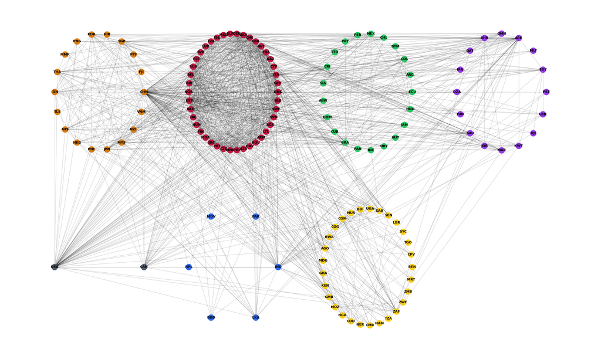

```python
tj.plot_trade_network(
    df_product_cleaned,
    product_df_cleaned,
    col_i="i",
    col_j="j",
    region_col="region",
    min_degree=3,
    figsize=(20, 12),
)
```

## 4. Fit the full-information planted-partition reference point

The full-information FCBM uses the empirical number of links inside and outside blocks. This is the reference/true parameter point in the paper.

```python
true_fit = tj.fit_true_params_full_constraints(
    product_df_cleaned,
    product_matrix,
    feature_col="fitness",
    region_col="region",
)

print("True params / full-information FCBM:")
for k in ["g", "beta", "gamma", "L_same_obs", "L_diff_obs", "L_total", "entropy", "loglik"]:
    if k in true_fit:
        print(f"{k}: {true_fit[k]}")

# The Jeffreys model is fitted with only the total number of links on unordered dyads.
total_links_upper = true_fit["L_total"]
true_params = true_fit
```

```
True params / full-information FCBM:
g: 0.15382546738140054
gamma: 2.632903048869461
L_same_obs: 406.0
L_diff_obs: 418.0
L_total: 824.0
entropy: 1457.6967231457147
loglik: -2168.2593917903505
```

## 5. Construct the Jeffreys feasible curve and select entropy points

The Jeffreys model uses only `L_total`, not the separate same-block and different-block counts.

```python
out = tj.run_jeffreys_pipeline(
    df_raw=product_df_cleaned,
    total_links=total_links_upper,
    g_range=np.linspace(1e-5, 3.5, 1000),
    feature_col="fitness",
    region_col="region",
    max_link_error=1e-6,
    true_params=true_params,
    resample_points=1000,
    auto_clip_g_to_feasible=True,
    adj_matrix=product_matrix,
)

df_points = out["df_points"]
df_curve = out["df_curve"]
df_curve_filtered = out["df_curve_filtered"]
df_s_uniform_exact = out["df_s_uniform_exact"]
hp = out["highlights"]

print("Jeffreys-uniform curve points:", len(df_s_uniform_exact))
print("Feasible scanned points:", len(df_curve_filtered))

display(pd.DataFrame([
    {k: p.get(k) for k in ["label", "g", "gamma", "entropy", "loglik"]}
    for p in hp
]).round(6))
```

```
Jeffreys-uniform curve points: 867
Feasible scanned points: 149
```

|  | label | g | gamma | entropy | loglik |
| --- | --- | --- | --- | --- | --- |
| 0 | Min Entropy | 0.000011 | 14.169546 | 818.892936 | -5934.293061 |
| 1 | Max Entropy | 0.365749 | -0.394990 | 1575.877548 | -2598.758221 |
| 2 | Mean Entropy | 0.105363 | 3.483021 | 1379.486129 | -2204.709012 |
| 3 | Median Entropy | 0.189228 | 2.093217 | 1497.801455 | -2182.907911 |
| 4 | True Params | 0.153825 | 2.632903 | 1457.696723 | -2168.259392 |

## 6. Plot entropy along the Jeffreys curve

These plots correspond to the entropy panels in the paper: 3D curve, entropy vs `exp(beta) = g`, and entropy vs `gamma`.

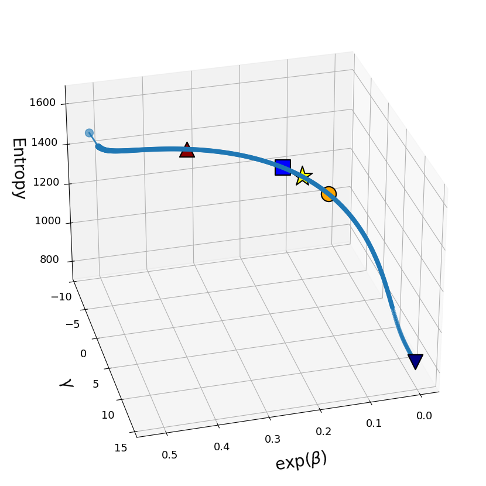

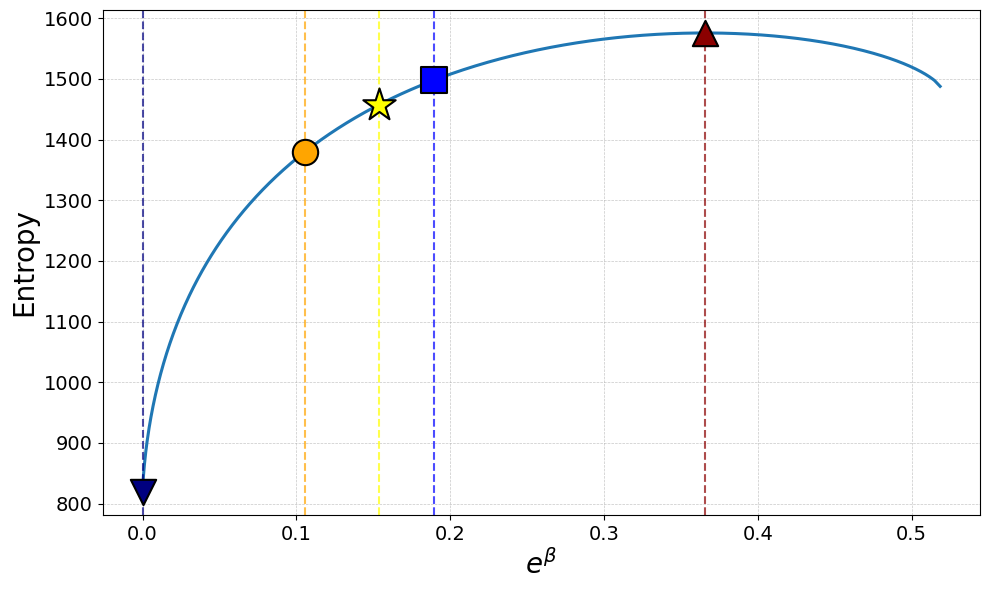

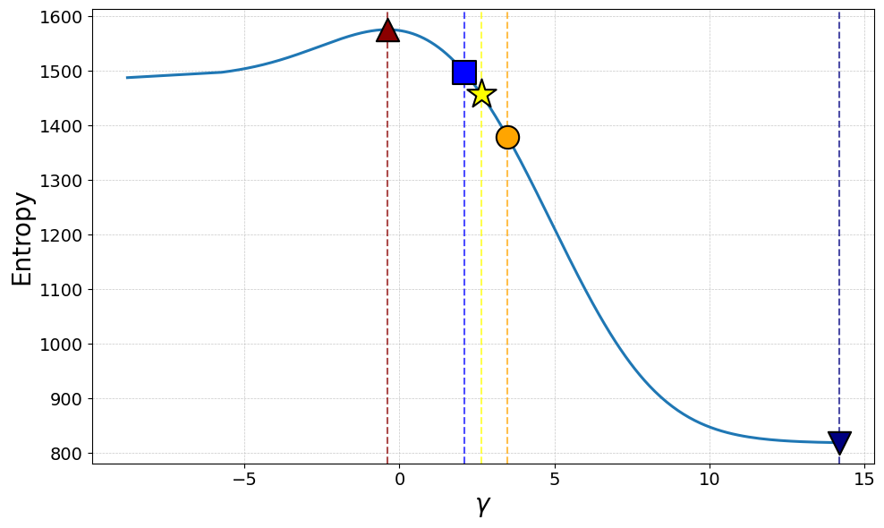

```python
tj.plot_curve_3d(
    df_s_uniform_exact,
    z_column="entropy",
    z_label="Entropy",
    highlight_points=hp,
    size_by="J_beta",
    connect_by="run_id",
    sort_within="beta",
    elev=30,
    azim=75,
    figsize=(14, 9),
)

tj.plot_curve_2d(
    df_s_uniform_exact,
    x_column="g",
    y_column="entropy",
    x_label=r"$e^{\beta}$",
    y_label="Entropy",
    highlight_points=hp,
    sort_within="beta",
    figsize=(10, 6),
)

tj.plot_curve_2d(
    df_s_uniform_exact,
    x_column="gamma",
    y_column="entropy",
    x_label=r"$\gamma$",
    y_label="Entropy",
    highlight_points=hp,
    sort_within="gamma",
    figsize=(10, 6),
)
```

## 7. Plot log-likelihood along the Jeffreys curve

These plots correspond to the log-likelihood panels in the paper.

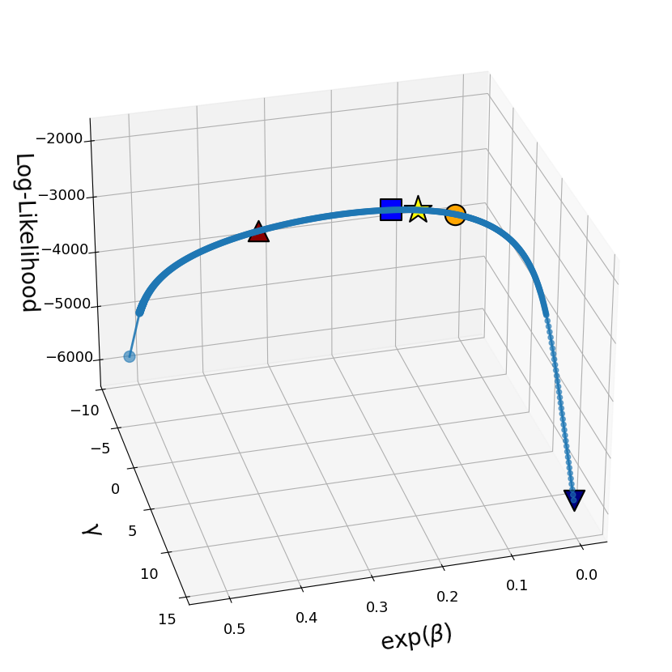

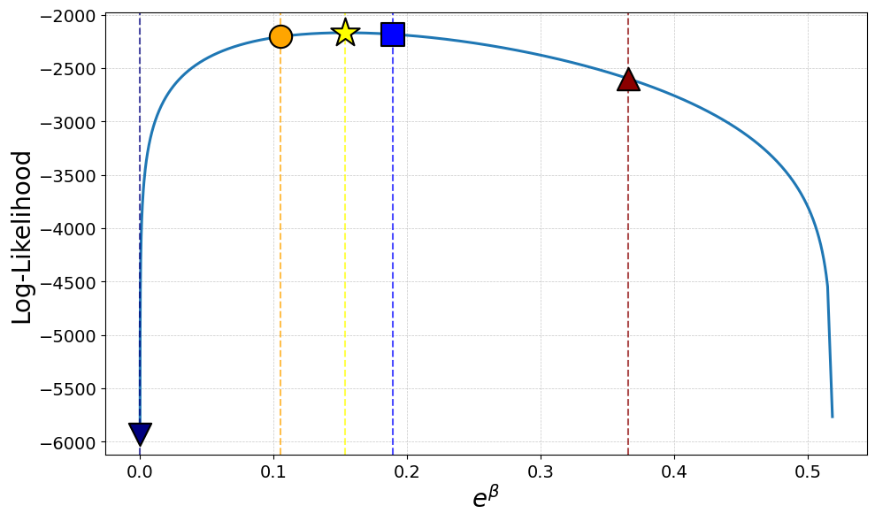

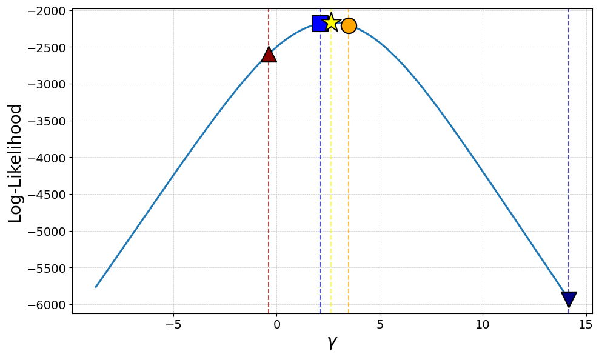

```python
tj.plot_curve_3d(
    df_s_uniform_exact,
    z_column="loglik",
    z_label="Log-Likelihood",
    highlight_points=hp,
    size_by="J_beta",
    connect_by="run_id",
    sort_within="beta",
    elev=30,
    azim=75,
    figsize=(14, 9),
)

tj.plot_curve_2d(
    df_s_uniform_exact,
    x_column="g",
    y_column="loglik",
    x_label=r"$e^{\beta}$",
    y_label="Log-Likelihood",
    highlight_points=hp,
    sort_within="beta",
    figsize=(10, 6),
)

tj.plot_curve_2d(
    df_s_uniform_exact,
    x_column="gamma",
    y_column="loglik",
    x_label=r"$\gamma$",
    y_label="Log-Likelihood",
    highlight_points=hp,
    sort_within="gamma",
    figsize=(10, 6),
)
```

## 8. Final model-comparison table

This reproduces the Wood 2020 results using the package utilities.

The ROC AUC and PR AUC are computed with the same matrix-flattening convention as the original exploratory notebook. AIC and BIC are computed on unordered dyads (`i < j`), with `N = n(n-1)/2` in the BIC penalty, matching Table 3 in the paper.

```python
g_fm = tj.fit_block_agnostic_fm(
    product_df_cleaned,
    adj_matrix=product_matrix,
    feature_col="fitness",
    mode="full",
)

median_hp = next(p for p in hp if p["label"] == "Median Entropy")

df_model_results = tj.paper_model_comparison_table(
    product_df_cleaned,
    product_matrix,
    g_fm=g_fm,
    g_median=median_hp["g"],
    gamma_median=median_hp["gamma"],
    g_true=true_fit["g"],
    gamma_true=true_fit["gamma"],
    feature_col="fitness",
    region_col="region",
)

display(df_model_results.round(6))
```

|  | Model | k | beta | g | gamma | ROC AUC | PR AUC | AIC | BIC |
| --- | --- | --- | --- | --- | --- | --- | --- | --- | --- |
| 0 | Block-Agnostic FM | 1 | -1.222486 | 0.294497 | 0.000000 | 0.878464 | 0.379592 | 5008.894131 | 5016.524826 |
| 1 | Jeffreys Prior & Median Entropy | 1 | -1.664803 | 0.189228 | 2.093217 | 0.909678 | 0.471444 | 4367.815822 | 4375.446516 |
| 2 | FCBM Planted Partition | 2 | -1.871937 | 0.153825 | 2.632903 | 0.913068 | 0.479878 | 4340.518784 | 4355.780172 |